# EDA on Zomato Dataset

### Importing important libraries

```python
import pandas as pd
import numpy as np
import matplotlib.pyplot as plt
import matplotlib
import seaborn as sns
%matplotlib inline
matplotlib.rcParams['figure.figsize'] = (12, 6)
```

**Dataset is taken from Kaggle in json format, coverted to 2 files: Zomato.csv and Country-code.excel**

```python
df = pd.read_csv('zomato.csv', encoding='latin-1')
```

```python
df.head()
```

|  | Restaurant ID | Restaurant Name | Country Code | City | Address | Locality | Locality Verbose | Longitude | Latitude | Cuisines | ... | Currency | Has Table booking | Has Online delivery | Is delivering now | Switch to order menu | Price range | Aggregate rating | Rating color | Rating text | Votes |
| --- | --- | --- | --- | --- | --- | --- | --- | --- | --- | --- | --- | --- | --- | --- | --- | --- | --- | --- | --- | --- | --- |
| 0 | 6317637 | Le Petit Souffle | 162 | Makati City | Third Floor, Century City Mall, Kalayaan Avenu... | Century City Mall, Poblacion, Makati City | Century City Mall, Poblacion, Makati City, Mak... | 121.027535 | 14.565443 | French, Japanese, Desserts | ... | Botswana Pula(P) | Yes | No | No | No | 3 | 4.8 | Dark Green | Excellent | 314 |
| 1 | 6304287 | Izakaya Kikufuji | 162 | Makati City | Little Tokyo, 2277 Chino Roces Avenue, Legaspi... | Little Tokyo, Legaspi Village, Makati City | Little Tokyo, Legaspi Village, Makati City, Ma... | 121.014101 | 14.553708 | Japanese | ... | Botswana Pula(P) | Yes | No | No | No | 3 | 4.5 | Dark Green | Excellent | 591 |
| 2 | 6300002 | Heat - Edsa Shangri-La | 162 | Mandaluyong City | Edsa Shangri-La, 1 Garden Way, Ortigas, Mandal... | Edsa Shangri-La, Ortigas, Mandaluyong City | Edsa Shangri-La, Ortigas, Mandaluyong City, Ma... | 121.056831 | 14.581404 | Seafood, Asian, Filipino, Indian | ... | Botswana Pula(P) | Yes | No | No | No | 4 | 4.4 | Green | Very Good | 270 |
| 3 | 6318506 | Ooma | 162 | Mandaluyong City | Third Floor, Mega Fashion Hall, SM Megamall, O... | SM Megamall, Ortigas, Mandaluyong City | SM Megamall, Ortigas, Mandaluyong City, Mandal... | 121.056475 | 14.585318 | Japanese, Sushi | ... | Botswana Pula(P) | No | No | No | No | 4 | 4.9 | Dark Green | Excellent | 365 |
| 4 | 6314302 | Sambo Kojin | 162 | Mandaluyong City | Third Floor, Mega Atrium, SM Megamall, Ortigas... | SM Megamall, Ortigas, Mandaluyong City | SM Megamall, Ortigas, Mandaluyong City, Mandal... | 121.057508 | 14.584450 | Japanese, Korean | ... | Botswana Pula(P) | Yes | No | No | No | 4 | 4.8 | Dark Green | Excellent | 229 |

5 rows × 21 columns

```python
df.shape
```

```
(9551, 21)
```

```python
df.columns
```

```
Index(['Restaurant ID', 'Restaurant Name', 'Country Code', 'City', 'Address',
       'Locality', 'Locality Verbose', 'Longitude', 'Latitude', 'Cuisines',
       'Average Cost for two', 'Currency', 'Has Table booking',
       'Has Online delivery', 'Is delivering now', 'Switch to order menu',
       'Price range', 'Aggregate rating', 'Rating color', 'Rating text',
       'Votes'],
      dtype='object')
```

```python
df.info()
```

```
<class 'pandas.core.frame.DataFrame'>
RangeIndex: 9551 entries, 0 to 9550
Data columns (total 21 columns):
 #   Column                Non-Null Count  Dtype
---  ------                --------------  -----
 0   Restaurant ID         9551 non-null   int64
 1   Restaurant Name       9551 non-null   object
 2   Country Code          9551 non-null   int64
 3   City                  9551 non-null   object
 4   Address               9551 non-null   object
 5   Locality              9551 non-null   object
 6   Locality Verbose      9551 non-null   object
 7   Longitude             9551 non-null   float64
 8   Latitude              9551 non-null   float64
 9   Cuisines              9542 non-null   object
 10  Average Cost for two  9551 non-null   int64
 11  Currency              9551 non-null   object
 12  Has Table booking     9551 non-null   object
 13  Has Online delivery   9551 non-null   object
 14  Is delivering now     9551 non-null   object
 15  Switch to order menu  9551 non-null   object
 16  Price range           9551 non-null   int64
 17  Aggregate rating      9551 non-null   float64
 18  Rating color          9551 non-null   object
 19  Rating text           9551 non-null   object
 20  Votes                 9551 non-null   int64
dtypes: float64(3), int64(5), object(13)
memory usage: 1.1+ MB
```

```python
df.describe()
```

|  | Restaurant ID | Country Code | Longitude | Latitude | Average Cost for two | Price range | Aggregate rating | Votes |
| --- | --- | --- | --- | --- | --- | --- | --- | --- |
| count | 9.551000e+03 | 9551.000000 | 9551.000000 | 9551.000000 | 9551.000000 | 9551.000000 | 9551.000000 | 9551.000000 |
| mean | 9.051128e+06 | 18.365616 | 64.126574 | 25.854381 | 1199.210763 | 1.804837 | 2.666370 | 156.909748 |
| std | 8.791521e+06 | 56.750546 | 41.467058 | 11.007935 | 16121.183073 | 0.905609 | 1.516378 | 430.169145 |
| min | 5.300000e+01 | 1.000000 | -157.948486 | -41.330428 | 0.000000 | 1.000000 | 0.000000 | 0.000000 |
| 25% | 3.019625e+05 | 1.000000 | 77.081343 | 28.478713 | 250.000000 | 1.000000 | 2.500000 | 5.000000 |
| 50% | 6.004089e+06 | 1.000000 | 77.191964 | 28.570469 | 400.000000 | 2.000000 | 3.200000 | 31.000000 |
| 75% | 1.835229e+07 | 1.000000 | 77.282006 | 28.642758 | 700.000000 | 2.000000 | 3.700000 | 131.000000 |
| max | 1.850065e+07 | 216.000000 | 174.832089 | 55.976980 | 800000.000000 | 4.000000 | 4.900000 | 10934.000000 |

### Data analysis include:

**1. Missing values** **2. Explore about numberical variable** **3. Explore about catagorical variable** **4. finding relationship b/n features**

### How i can find missing values

**1. Using isnull func** **2. Using query** **3. Using heatmap**

```python
# using isnull func
df.isnull().sum()
```

```
Restaurant ID           0
Restaurant Name         0
Country Code            0
City                    0
Address                 0
Locality                0
Locality Verbose        0
Longitude               0
Latitude                0
Cuisines                9
Average Cost for two    0
Currency                0
Has Table booking       0
Has Online delivery     0
Is delivering now       0
Switch to order menu    0
Price range             0
Aggregate rating        0
Rating color            0
Rating text             0
Votes                   0
dtype: int64
```

**In cusines, there are 9 missing values.

```python
#using query
features = []
for col in df.columns:
    if df[col].isnull().sum()>0:
        features.append(col)


print(features)
```

```
['Cuisines']
```

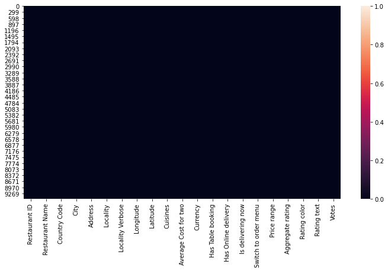

```python
#using heatmap
sns.heatmap(df.isnull())
```

There are only 9 missing values, for that reason it is not visible

# Importing Country Code data

```python
df_country = pd.read_excel('Country-Code.xlsx')
```

```python
df_country.head()
```

|  | Country Code | Country |
| --- | --- | --- |
| 0 | 1 | India |
| 1 | 14 | Australia |
| 2 | 30 | Brazil |
| 3 | 37 | Canada |
| 4 | 94 | Indonesia |

```python
df['Country Code'].value_counts()
```

```
1      8652
216     434
215      80
189      60
30       60
214      60
148      40
208      34
14       24
162      22
94       21
184      20
166      20
191      20
37        4
Name: Country Code, dtype: int64
```

### Merging 2 table: Zomato.csv and Country code.xlsx

```python
final_df = pd.merge(df, df_country, on="Country Code", how="left")
```

```python
final_df.head()
```

|  | Restaurant ID | Restaurant Name | Country Code | City | Address | Locality | Locality Verbose | Longitude | Latitude | Cuisines | ... | Has Table booking | Has Online delivery | Is delivering now | Switch to order menu | Price range | Aggregate rating | Rating color | Rating text | Votes | Country |
| --- | --- | --- | --- | --- | --- | --- | --- | --- | --- | --- | --- | --- | --- | --- | --- | --- | --- | --- | --- | --- | --- |
| 0 | 6317637 | Le Petit Souffle | 162 | Makati City | Third Floor, Century City Mall, Kalayaan Avenu... | Century City Mall, Poblacion, Makati City | Century City Mall, Poblacion, Makati City, Mak... | 121.027535 | 14.565443 | French, Japanese, Desserts | ... | Yes | No | No | No | 3 | 4.8 | Dark Green | Excellent | 314 | Phillipines |
| 1 | 6304287 | Izakaya Kikufuji | 162 | Makati City | Little Tokyo, 2277 Chino Roces Avenue, Legaspi... | Little Tokyo, Legaspi Village, Makati City | Little Tokyo, Legaspi Village, Makati City, Ma... | 121.014101 | 14.553708 | Japanese | ... | Yes | No | No | No | 3 | 4.5 | Dark Green | Excellent | 591 | Phillipines |
| 2 | 6300002 | Heat - Edsa Shangri-La | 162 | Mandaluyong City | Edsa Shangri-La, 1 Garden Way, Ortigas, Mandal... | Edsa Shangri-La, Ortigas, Mandaluyong City | Edsa Shangri-La, Ortigas, Mandaluyong City, Ma... | 121.056831 | 14.581404 | Seafood, Asian, Filipino, Indian | ... | Yes | No | No | No | 4 | 4.4 | Green | Very Good | 270 | Phillipines |
| 3 | 6318506 | Ooma | 162 | Mandaluyong City | Third Floor, Mega Fashion Hall, SM Megamall, O... | SM Megamall, Ortigas, Mandaluyong City | SM Megamall, Ortigas, Mandaluyong City, Mandal... | 121.056475 | 14.585318 | Japanese, Sushi | ... | No | No | No | No | 4 | 4.9 | Dark Green | Excellent | 365 | Phillipines |
| 4 | 6314302 | Sambo Kojin | 162 | Mandaluyong City | Third Floor, Mega Atrium, SM Megamall, Ortigas... | SM Megamall, Ortigas, Mandaluyong City | SM Megamall, Ortigas, Mandaluyong City, Mandal... | 121.057508 | 14.584450 | Japanese, Korean | ... | Yes | No | No | No | 4 | 4.8 | Dark Green | Excellent | 229 | Phillipines |

5 rows × 22 columns

### Exploring Features in final_df

```python
final_df.info()
```

```
<class 'pandas.core.frame.DataFrame'>
Int64Index: 9551 entries, 0 to 9550
Data columns (total 22 columns):
 #   Column                Non-Null Count  Dtype
---  ------                --------------  -----
 0   Restaurant ID         9551 non-null   int64
 1   Restaurant Name       9551 non-null   object
 2   Country Code          9551 non-null   int64
 3   City                  9551 non-null   object
 4   Address               9551 non-null   object
 5   Locality              9551 non-null   object
 6   Locality Verbose      9551 non-null   object
 7   Longitude             9551 non-null   float64
 8   Latitude              9551 non-null   float64
 9   Cuisines              9542 non-null   object
 10  Average Cost for two  9551 non-null   int64
 11  Currency              9551 non-null   object
 12  Has Table booking     9551 non-null   object
 13  Has Online delivery   9551 non-null   object
 14  Is delivering now     9551 non-null   object
 15  Switch to order menu  9551 non-null   object
 16  Price range           9551 non-null   int64
 17  Aggregate rating      9551 non-null   float64
 18  Rating color          9551 non-null   object
 19  Rating text           9551 non-null   object
 20  Votes                 9551 non-null   int64
 21  Country               9551 non-null   object
dtypes: float64(3), int64(5), object(14)
memory usage: 1.2+ MB
```

```python
final_df.Country.value_counts()
```

```
India             8652
United States      434
United Kingdom      80
South Africa        60
Brazil              60
UAE                 60
New Zealand         40
Turkey              34
Australia           24
Phillipines         22
Indonesia           21
Qatar               20
Sri Lanka           20
Singapore           20
Canada               4
Name: Country, dtype: int64
```

```python
final_df.Country.value_counts().index
```

```
Index(['India', 'United States', 'United Kingdom', 'South Africa', 'Brazil',
       'UAE', 'New Zealand', 'Turkey', 'Australia', 'Phillipines', 'Indonesia',
       'Qatar', 'Sri Lanka', 'Singapore', 'Canada'],
      dtype='object')
```

### Which country has maximum number of orders?

**1. Using pandas** **2. Using pie chart**

```python
country_names = final_df.Country.value_counts().index
country_names
```

```
Index(['India', 'United States', 'United Kingdom', 'South Africa', 'Brazil',
       'UAE', 'New Zealand', 'Turkey', 'Australia', 'Phillipines', 'Indonesia',
       'Qatar', 'Sri Lanka', 'Singapore', 'Canada'],
      dtype='object')
```

```python
country_names_counts = final_df.Country.value_counts().values
country_names_counts
```

```
array([8652,  434,   80,   60,   60,   60,   40,   34,   24,   22,   21,
         20,   20,   20,    4], dtype=int64)
```

```
 [Text(-1.052256163793291, 0.3205572737577906, 'India'),
```

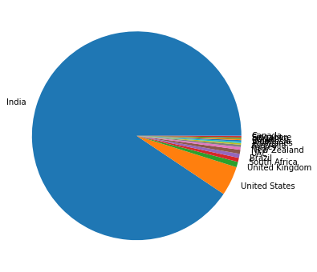

```python
plt.pie(country_names_counts, labels=country_names)
```

**The above pie chart is bit messy so we are finding top 3 countries that has maximum orders**

```
 [Text(-1.0829742700952103, 0.19278674827836725, 'India'),
 [Text(-0.590713238233751, 0.10515640815183668, '94.392%'),
```

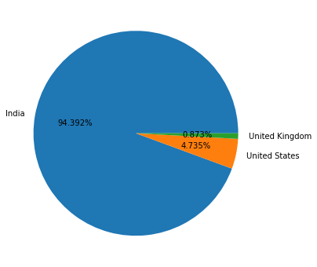

```python
plt.pie(country_names_counts[:3], labels=country_names[:3], autopct="%1.3f%%")
```

**Observation India has maximum number of orders, then USA, then United Kingdom**

### Numberical Variables

```python
final_df.head()
```

|  | Restaurant ID | Restaurant Name | Country Code | City | Address | Locality | Locality Verbose | Longitude | Latitude | Cuisines | ... | Has Table booking | Has Online delivery | Is delivering now | Switch to order menu | Price range | Aggregate rating | Rating color | Rating text | Votes | Country |
| --- | --- | --- | --- | --- | --- | --- | --- | --- | --- | --- | --- | --- | --- | --- | --- | --- | --- | --- | --- | --- | --- |
| 0 | 6317637 | Le Petit Souffle | 162 | Makati City | Third Floor, Century City Mall, Kalayaan Avenu... | Century City Mall, Poblacion, Makati City | Century City Mall, Poblacion, Makati City, Mak... | 121.027535 | 14.565443 | French, Japanese, Desserts | ... | Yes | No | No | No | 3 | 4.8 | Dark Green | Excellent | 314 | Phillipines |
| 1 | 6304287 | Izakaya Kikufuji | 162 | Makati City | Little Tokyo, 2277 Chino Roces Avenue, Legaspi... | Little Tokyo, Legaspi Village, Makati City | Little Tokyo, Legaspi Village, Makati City, Ma... | 121.014101 | 14.553708 | Japanese | ... | Yes | No | No | No | 3 | 4.5 | Dark Green | Excellent | 591 | Phillipines |
| 2 | 6300002 | Heat - Edsa Shangri-La | 162 | Mandaluyong City | Edsa Shangri-La, 1 Garden Way, Ortigas, Mandal... | Edsa Shangri-La, Ortigas, Mandaluyong City | Edsa Shangri-La, Ortigas, Mandaluyong City, Ma... | 121.056831 | 14.581404 | Seafood, Asian, Filipino, Indian | ... | Yes | No | No | No | 4 | 4.4 | Green | Very Good | 270 | Phillipines |
| 3 | 6318506 | Ooma | 162 | Mandaluyong City | Third Floor, Mega Fashion Hall, SM Megamall, O... | SM Megamall, Ortigas, Mandaluyong City | SM Megamall, Ortigas, Mandaluyong City, Mandal... | 121.056475 | 14.585318 | Japanese, Sushi | ... | No | No | No | No | 4 | 4.9 | Dark Green | Excellent | 365 | Phillipines |
| 4 | 6314302 | Sambo Kojin | 162 | Mandaluyong City | Third Floor, Mega Atrium, SM Megamall, Ortigas... | SM Megamall, Ortigas, Mandaluyong City | SM Megamall, Ortigas, Mandaluyong City, Mandal... | 121.057508 | 14.584450 | Japanese, Korean | ... | Yes | No | No | No | 4 | 4.8 | Dark Green | Excellent | 229 | Phillipines |

5 rows × 22 columns

```python
final_df["Aggregate rating"].value_counts()
```

```
0.0    2148
3.2     522
3.1     519
3.4     498
3.3     483
3.5     480
3.0     468
3.6     458
3.7     427
3.8     400
2.9     381
3.9     335
2.8     315
4.1     274
4.0     266
2.7     250
4.2     221
2.6     191
4.3     174
4.4     144
2.5     110
4.5      95
2.4      87
4.6      78
4.9      61
2.3      47
4.7      42
2.2      27
4.8      25
2.1      15
2.0       7
1.9       2
1.8       1
Name: Aggregate rating, dtype: int64
```

```python
final_df["Rating color"].value_counts()
```

```
Orange        3737
White         2148
Yellow        2100
Green         1079
Dark Green     301
Red            186
Name: Rating color, dtype: int64
```

```python
final_df["Rating text"].value_counts()
```

```
Average      3737
Not rated    2148
Good         2100
Very Good    1079
Excellent     301
Poor          186
Name: Rating text, dtype: int64
```

```python
ratings = final_df.groupby(['Aggregate rating', 'Rating color', 'Rating text']).size().reset_index().rename(columns={0:"Rating Count"})
ratings
```

|  | Aggregate rating | Rating color | Rating text | Rating Count |
| --- | --- | --- | --- | --- |
| 0 | 0.0 | White | Not rated | 2148 |
| 1 | 1.8 | Red | Poor | 1 |
| 2 | 1.9 | Red | Poor | 2 |
| 3 | 2.0 | Red | Poor | 7 |
| 4 | 2.1 | Red | Poor | 15 |
| 5 | 2.2 | Red | Poor | 27 |
| 6 | 2.3 | Red | Poor | 47 |
| 7 | 2.4 | Red | Poor | 87 |
| 8 | 2.5 | Orange | Average | 110 |
| 9 | 2.6 | Orange | Average | 191 |
| 10 | 2.7 | Orange | Average | 250 |
| 11 | 2.8 | Orange | Average | 315 |
| 12 | 2.9 | Orange | Average | 381 |
| 13 | 3.0 | Orange | Average | 468 |
| 14 | 3.1 | Orange | Average | 519 |
| 15 | 3.2 | Orange | Average | 522 |
| 16 | 3.3 | Orange | Average | 483 |
| 17 | 3.4 | Orange | Average | 498 |
| 18 | 3.5 | Yellow | Good | 480 |
| 19 | 3.6 | Yellow | Good | 458 |
| 20 | 3.7 | Yellow | Good | 427 |
| 21 | 3.8 | Yellow | Good | 400 |
| 22 | 3.9 | Yellow | Good | 335 |
| 23 | 4.0 | Green | Very Good | 266 |
| 24 | 4.1 | Green | Very Good | 274 |
| 25 | 4.2 | Green | Very Good | 221 |
| 26 | 4.3 | Green | Very Good | 174 |
| 27 | 4.4 | Green | Very Good | 144 |
| 28 | 4.5 | Dark Green | Excellent | 95 |
| 29 | 4.6 | Dark Green | Excellent | 78 |
| 30 | 4.7 | Dark Green | Excellent | 42 |
| 31 | 4.8 | Dark Green | Excellent | 25 |
| 32 | 4.9 | Dark Green | Excellent | 61 |

## Observation

1. 2148 users has not given rating ---> We need to work on it.
2. When rating is between 4.5 to 4.9 --> Excellent
3. When rating is between 4 to 4.4 --> Very good
4. When rating is between 3.5 to 3.9 --> good
5. When rating is between 2.5 to 3.4 --> average
6. When rating is between 1.8 to 2.4 --> poor
7. No customer rated 5.

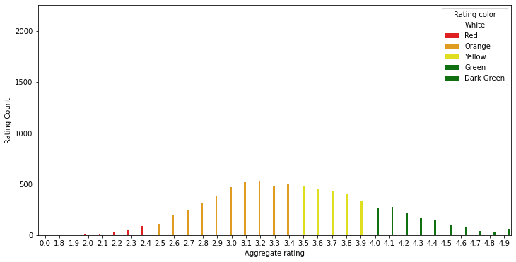

```python
# Using bar to visulize
sns.barplot(x="Aggregate rating", y="Rating Count", hue="Rating color", data=ratings, palette=['White', 'Red', 'Orange', 'Yellow', 'Green', 'Green'])
```

Observation: Maximum rating is between 2.5 to 3.9

### Ques: How many users has given 0.0 rating? which country they belong?

```python
# Method 1
res = final_df['Country'][final_df['Aggregate rating'] == 0.0]
res.count()
```

```
2148
```

2148 users has given 0.0 rating.

```python
#Method 2
ct = final_df[final_df['Aggregate rating'] == 0.0]
ct.count()
```

```
Restaurant ID           2148
Restaurant Name         2148
Country Code            2148
City                    2148
Address                 2148
Locality                2148
Locality Verbose        2148
Longitude               2148
Latitude                2148
Cuisines                2148
Average Cost for two    2148
Currency                2148
Has Table booking       2148
Has Online delivery     2148
Is delivering now       2148
Switch to order menu    2148
Price range             2148
Aggregate rating        2148
Rating color            2148
Rating text             2148
Votes                   2148
Country                 2148
dtype: int64
```

```python
#Method 3
x = final_df[final_df['Rating color'] == 'White'].groupby("Country").size().reset_index()
x
```

|  | Country | 0 |
| --- | --- | --- |
| 0 | Brazil | 5 |
| 1 | India | 2139 |
| 2 | United Kingdom | 1 |
| 3 | United States | 3 |

```python
#Method 4
final_df.groupby(['Aggregate rating', 'Country']).size().reset_index().rename(columns={0:"Counts"})
```

|  | Aggregate rating | Country | Counts |
| --- | --- | --- | --- |
| 0 | 0.0 | Brazil | 5 |
| 1 | 0.0 | India | 2139 |
| 2 | 0.0 | United Kingdom | 1 |
| 3 | 0.0 | United States | 3 |
| 4 | 1.8 | India | 1 |
| ... | ... | ... | ... |
| 217 | 4.9 | Sri Lanka | 1 |
| 218 | 4.9 | Turkey | 3 |
| 219 | 4.9 | UAE | 4 |
| 220 | 4.9 | United Kingdom | 4 |
| 221 | 4.9 | United States | 14 |

222 rows × 3 columns

### Observation

Maximum number of 0 rating are from Indian customers

### Ques: Which currency is used by which country?

```python
final_df.head(50)
```

|  | Restaurant ID | Restaurant Name | Country Code | City | Address | Locality | Locality Verbose | Longitude | Latitude | Cuisines | ... | Has Table booking | Has Online delivery | Is delivering now | Switch to order menu | Price range | Aggregate rating | Rating color | Rating text | Votes | Country |
| --- | --- | --- | --- | --- | --- | --- | --- | --- | --- | --- | --- | --- | --- | --- | --- | --- | --- | --- | --- | --- | --- |
| 0 | 6317637 | Le Petit Souffle | 162 | Makati City | Third Floor, Century City Mall, Kalayaan Avenu... | Century City Mall, Poblacion, Makati City | Century City Mall, Poblacion, Makati City, Mak... | 121.027535 | 14.565443 | French, Japanese, Desserts | ... | Yes | No | No | No | 3 | 4.8 | Dark Green | Excellent | 314 | Phillipines |
| 1 | 6304287 | Izakaya Kikufuji | 162 | Makati City | Little Tokyo, 2277 Chino Roces Avenue, Legaspi... | Little Tokyo, Legaspi Village, Makati City | Little Tokyo, Legaspi Village, Makati City, Ma... | 121.014101 | 14.553708 | Japanese | ... | Yes | No | No | No | 3 | 4.5 | Dark Green | Excellent | 591 | Phillipines |
| 2 | 6300002 | Heat - Edsa Shangri-La | 162 | Mandaluyong City | Edsa Shangri-La, 1 Garden Way, Ortigas, Mandal... | Edsa Shangri-La, Ortigas, Mandaluyong City | Edsa Shangri-La, Ortigas, Mandaluyong City, Ma... | 121.056831 | 14.581404 | Seafood, Asian, Filipino, Indian | ... | Yes | No | No | No | 4 | 4.4 | Green | Very Good | 270 | Phillipines |
| 3 | 6318506 | Ooma | 162 | Mandaluyong City | Third Floor, Mega Fashion Hall, SM Megamall, O... | SM Megamall, Ortigas, Mandaluyong City | SM Megamall, Ortigas, Mandaluyong City, Mandal... | 121.056475 | 14.585318 | Japanese, Sushi | ... | No | No | No | No | 4 | 4.9 | Dark Green | Excellent | 365 | Phillipines |
| 4 | 6314302 | Sambo Kojin | 162 | Mandaluyong City | Third Floor, Mega Atrium, SM Megamall, Ortigas... | SM Megamall, Ortigas, Mandaluyong City | SM Megamall, Ortigas, Mandaluyong City, Mandal... | 121.057508 | 14.584450 | Japanese, Korean | ... | Yes | No | No | No | 4 | 4.8 | Dark Green | Excellent | 229 | Phillipines |
| 5 | 18189371 | Din Tai Fung | 162 | Mandaluyong City | Ground Floor, Mega Fashion Hall, SM Megamall, ... | SM Megamall, Ortigas, Mandaluyong City | SM Megamall, Ortigas, Mandaluyong City, Mandal... | 121.056314 | 14.583764 | Chinese | ... | No | No | No | No | 3 | 4.4 | Green | Very Good | 336 | Phillipines |
| 6 | 6300781 | Buffet 101 | 162 | Pasay City | Building K, SM By The Bay, Sunset Boulevard, M... | SM by the Bay, Mall of Asia Complex, Pasay City | SM by the Bay, Mall of Asia Complex, Pasay Cit... | 120.979667 | 14.531333 | Asian, European | ... | Yes | No | No | No | 4 | 4.0 | Green | Very Good | 520 | Phillipines |
| 7 | 6301290 | Vikings | 162 | Pasay City | Building B, By The Bay, Seaside Boulevard, Mal... | SM by the Bay, Mall of Asia Complex, Pasay City | SM by the Bay, Mall of Asia Complex, Pasay Cit... | 120.979333 | 14.540000 | Seafood, Filipino, Asian, European | ... | Yes | No | No | No | 4 | 4.2 | Green | Very Good | 677 | Phillipines |
| 8 | 6300010 | Spiral - Sofitel Philippine Plaza Manila | 162 | Pasay City | Plaza Level, Sofitel Philippine Plaza Manila, ... | Sofitel Philippine Plaza Manila, Pasay City | Sofitel Philippine Plaza Manila, Pasay City, P... | 120.980090 | 14.552990 | European, Asian, Indian | ... | Yes | No | No | No | 4 | 4.9 | Dark Green | Excellent | 621 | Phillipines |
| 9 | 6314987 | Locavore | 162 | Pasig City | Brixton Technology Center, 10 Brixton Street, ... | Kapitolyo | Kapitolyo, Pasig City | 121.056532 | 14.572041 | Filipino | ... | Yes | No | No | No | 3 | 4.8 | Dark Green | Excellent | 532 | Phillipines |
| 10 | 6309903 | Silantro Fil-Mex | 162 | Pasig City | 75 East Capitol Drive, Kapitolyo, Pasig City | Kapitolyo | Kapitolyo, Pasig City | 121.057916 | 14.567689 | Filipino, Mexican | ... | No | No | No | No | 3 | 4.9 | Dark Green | Excellent | 1070 | Phillipines |
| 11 | 6309455 | Mad Mark's Creamery & Good Eats | 162 | Pasig City | 23 East Capitol Drive, Kapitolyo, Pasig City | Kapitolyo | Kapitolyo, Pasig City | 121.060820 | 14.570849 | American, Ice Cream, Desserts | ... | Yes | No | No | No | 3 | 4.2 | Green | Very Good | 488 | Phillipines |
| 12 | 6318433 | Silantro Fil-Mex | 162 | Quezon City | Second Floor, UP Town Center, Katipunan Avenue... | UP Town Center, Diliman, Quezon City | UP Town Center, Diliman, Quezon City, Quezon City | 121.075419 | 14.649503 | Filipino, Mexican | ... | No | No | No | No | 3 | 4.8 | Dark Green | Excellent | 294 | Phillipines |
| 13 | 6310470 | Guevarra's | 162 | San Juan City | 387 P. Guevarra Corner Argonne Street, Additio... | Addition Hills | Addition Hills, San Juan City | 121.033592 | 14.593450 | Filipino | ... | Yes | No | No | No | 3 | 4.2 | Green | Very Good | 458 | Phillipines |
| 14 | 6314605 | Sodam Korean Restaurant | 162 | San Juan City | 17 J. Abad Santos Drive, Little Baguio, San Ju... | Little Baguio | Little Baguio, San Juan City | 121.038110 | 14.598890 | Korean | ... | No | No | No | No | 3 | 4.3 | Green | Very Good | 223 | Phillipines |
| 15 | 18185059 | Cafe Arabelle | 162 | Santa Rosa | Ayala Mall, Solenad, Nuvali, Santa Rosa - Taga... | Nuvali, Don Jose, Santa Rosa | Nuvali, Don Jose, Santa Rosa, Santa Rosa | 121.057040 | 14.237082 | Cafe, American, Italian, Filipino | ... | No | No | No | No | 3 | 3.6 | Yellow | Good | 29 | Phillipines |
| 16 | 18182702 | Nonna's Pasta & Pizzeria | 162 | Santa Rosa | Ground Floor, Building G, Solenad 3, Nuvali, D... | Solenad 3, Don Jose, Santa Rosa | Solenad 3, Don Jose, Santa Rosa, Santa Rosa | 121.056587 | 14.237679 | Italian, Pizza | ... | No | No | No | No | 3 | 4.0 | Green | Very Good | 72 | Phillipines |
| 17 | 6318213 | Balay Dako | 162 | Tagaytay City | Aguinaldo Highway, Tagaytay City | Tagaytay City | Tagaytay City, Tagaytay City | 120.951589 | 14.101834 | Filipino | ... | Yes | No | No | No | 3 | 4.5 | Dark Green | Excellent | 211 | Phillipines |
| 18 | 18255654 | Hobing Korean Dessert Cafe | 162 | Taguig City | Third Floor, BGC Stopover Pavillion, Rizal Dri... | BGC Stopover Pavillion, Bonifacio Global City | BGC Stopover Pavillion, Bonifacio Global City,... | 121.045878 | 14.554360 | Cafe, Korean, Desserts | ... | No | No | No | No | 2 | 4.5 | Dark Green | Excellent | 118 | Phillipines |
| 19 | 6308205 | Wildflour Cafe + Bakery | 162 | Taguig City | Ground Floor, Netlima Building, 4th Avenue Cor... | Bonifacio Global City | Bonifacio Global City, Taguig City | 121.046220 | 14.549337 | Cafe, Bakery, American, Italian | ... | Yes | No | No | No | 4 | 4.4 | Green | Very Good | 392 | Phillipines |
| 20 | 6315438 | NIU by Vikings | 162 | Taguig City | Sixth Floor, SM Aura Premier, C5 Road Corner 2... | SM Aura Premier, Bonifacio Global City, Taguig... | SM Aura Premier, Bonifacio Global City, Taguig... | 121.053725 | 14.545858 | Seafood, American, Mediterranean, Japanese | ... | Yes | No | No | No | 4 | 4.7 | Dark Green | Excellent | 535 | Phillipines |
| 21 | 6310406 | The Food Hall by Todd English | 162 | Taguig City | Fifth Floor, SM Aura Premier, C5 Corner 26th S... | SM Aura Premier, Bonifacio Global City, Taguig... | SM Aura Premier, Bonifacio Global City, Taguig... | 121.053500 | 14.545655 | American, Asian, Italian, Seafood | ... | Yes | No | No | No | 4 | 4.5 | Dark Green | Excellent | 618 | Phillipines |
| 22 | 6600681 | Chez Michou | 30 | Brasí_lia | SCLN, 208, Bloco A, Loja 30, Asa Norte, Brasí_lia | Asa Norte | Asa Norte, Brasí_lia | -47.881789 | -15.764142 | Fast Food, French | ... | No | No | No | No | 2 | 3.0 | Orange | Average | 6 | Brazil |
| 23 | 6601005 | Cafí© Daniel Briand | 30 | Brasí_lia | SCLN 104, Bloco A, Loja 26, Asa Norte, Brasí_lia | Asa Norte | Asa Norte, Brasí_lia | -47.882667 | -15.777500 | Cafe | ... | No | No | No | No | 1 | 3.8 | Yellow | Good | 9 | Brazil |
| 24 | 6600292 | Casa do Biscoito Mineiro | 30 | Brasí_lia | SCLN 210, Bloco D, Loja 36/48, Asa Norte, Bras... | Asa Norte | Asa Norte, Brasí_lia | -47.882136 | -15.757472 | Bakery | ... | No | No | No | No | 2 | 3.7 | Yellow | Good | 11 | Brazil |
| 25 | 6600441 | Maori | 30 | Brasí_lia | CLN 110, Bloco D, Loja 28, Asa Norte, Brasí_lia | Asa Norte | Asa Norte, Brasí_lia | -47.888167 | -15.758833 | Brazilian | ... | No | No | No | No | 3 | 3.8 | Yellow | Good | 11 | Brazil |
| 26 | 6600970 | Pizza íæ Bessa | 30 | Brasí_lia | SCS 214, Bloco C, Loja 40, Asa Sul, Brasí_lia | Asa Sul | Asa Sul, Brasí_lia | -47.915667 | -15.831167 | Pizza | ... | No | No | No | No | 2 | 3.2 | Orange | Average | 11 | Brazil |
| 27 | 6600379 | Sushi Loko | 30 | Brasí_lia | SCS 213, Bloco C, Loja 35, Asa Sul, Brasí_lia | Asa Sul | Asa Sul, Brasí_lia | -47.915667 | -15.831000 | Japanese | ... | No | No | No | No | 3 | 3.1 | Orange | Average | 10 | Brazil |
| 28 | 6600214 | Beirute | 30 | Brasí_lia | CLS 109, Bloco A, Loja 2/6, Asa Sul, Brasí_lia | Asa Sul | Asa Sul, Brasí_lia | -47.907500 | -15.820000 | Arabian | ... | No | No | No | No | 3 | 3.7 | Yellow | Good | 8 | Brazil |
| 29 | 6601218 | New Koto | 30 | Brasí_lia | SCS 212, Bloco B, Loja 26, Asa Sul, Brasí_lia | Asa Sul | Asa Sul, Brasí_lia | -47.910167 | -15.827333 | Japanese | ... | No | No | No | No | 4 | 3.7 | Yellow | Good | 5 | Brazil |
| 30 | 6600060 | Sandubas Cafí© | 30 | Brasí_lia | Edifí_cio Josí© Severo, SCS 6, Bloco A, Loja 9... | Asa Sul | Asa Sul, Brasí_lia | -47.890167 | -15.797000 | Brazilian, Cafe | ... | No | No | No | No | 1 | 0.0 | White | Not rated | 2 | Brazil |
| 31 | 6600083 | Villa Tevere | 30 | Brasí_lia | CLS 115, Bloco A, Loja 2, Asa Sul, Brasí_lia | Asa Sul | Asa Sul, Brasí_lia | -47.923667 | -15.831333 | Italian | ... | No | No | No | No | 4 | 4.1 | Green | Very Good | 12 | Brazil |
| 32 | 6601515 | Rovereto | 30 | Brasí_lia | Rua 13 Norte, Lote 4, íguas Claras, Brasí_lia | íguas Claras | íguas Claras, Brasí_lia | -48.019000 | -15.837167 | Pizza | ... | No | No | No | No | 4 | 3.1 | Orange | Average | 9 | Brazil |
| 33 | 6601361 | Buena Carne | 30 | Brasí_lia | Avenida Araucíçrias, 1325, Loja 19, íguas Cla... | íguas Claras | íguas Claras, Brasí_lia | -48.019092 | -15.839775 | Bar Food, Brazilian | ... | No | No | No | No | 3 | 3.6 | Yellow | Good | 9 | Brazil |
| 34 | 6601602 | Taco Pep | 30 | Brasí_lia | Vila Malls, Avenida das Castanheiras, Lote 106... | íguas Claras | íguas Claras, Brasí_lia | -48.016667 | -15.834833 | Mexican, Grill | ... | No | No | No | No | 4 | 4.3 | Green | Very Good | 29 | Brazil |
| 35 | 6601589 | Coco Bambu | 30 | Brasí_lia | Brasí_lia Shopping - Piso 2, SCN 5, Bloco A, A... | Brasí_lia Shopping, Asa Norte | Brasí_lia Shopping, Asa Norte, Brasí_lia | -47.889000 | -15.786500 | International | ... | No | No | No | No | 4 | 4.2 | Green | Very Good | 17 | Brazil |
| 36 | 6601862 | Taypíç | 30 | Brasí_lia | Fashion Park, Shis Ql 17, Bloco G, Loja 208, L... | Lago Sul | Lago Sul, Brasí_lia | -47.872359 | -15.860621 | Peruvian, Latin American | ... | No | No | No | No | 4 | 3.6 | Yellow | Good | 5 | Brazil |
| 37 | 6601595 | Outback Steakhouse | 30 | Brasí_lia | ParkShopping - Piso 2, SAI/SO, írea 6580, Gua... | ParkShopping, Guaríç I | ParkShopping, Guaríç I, Brasí_lia | -47.956283 | -15.834514 | American, Grill | ... | No | No | No | No | 4 | 4.0 | Green | Very Good | 10 | Brazil |
| 38 | 6601158 | Manzuíç | 30 | Brasí_lia | Pontí£o Lago Sul, SHIS 10, Lote 9, Lago Sul, B... | Pontí£o Lago Sul, Lago Sul | Pontí£o Lago Sul, Lago Sul, Brasí_lia | -47.872833 | -15.825667 | Seafood | ... | No | No | No | No | 4 | 3.2 | Orange | Average | 6 | Brazil |
| 39 | 6600427 | Coco Bambu | 30 | Brasí_lia | SCES, Trecho 2, Conjunto 13/36, Setor de Clube... | Setor De Clubes Esportivos Sul | Setor De Clubes Esportivos Sul, Brasí_lia | -47.868500 | -15.819000 | International | ... | No | No | No | No | 4 | 4.9 | Dark Green | Excellent | 30 | Brazil |
| 40 | 6600116 | Gero | 30 | Brasí_lia | Shopping Iguatemi - piso 1, SHIN CA 4, Lote A,... | Shopping Iguatemi, Lago Norte | Shopping Iguatemi, Lago Norte, Brasí_lia | -47.885812 | -15.720118 | Italian | ... | No | No | No | No | 4 | 3.3 | Orange | Average | 8 | Brazil |
| 41 | 6601457 | Brazilian American Burgers | 30 | Brasí_lia | CLSN 301, Bloco C, Loja 86, Sudoeste, Brasí_lia | Sudoeste | Sudoeste, Brasí_lia | -47.921028 | -15.797531 | American, Burger | ... | No | No | No | No | 2 | 3.6 | Yellow | Good | 9 | Brazil |
| 42 | 7303219 | Pesqueiro Eco Gourmet | 30 | Rio de Janeiro | Praia da Barra da Tijuca, Avenida Lí_cio Costa... | Barra da Tijuca | Barra da Tijuca, Rio de Janeiro | -43.377000 | -23.011500 | Seafood, Bar Food, Brazilian | ... | No | No | No | No | 4 | 4.0 | Green | Very Good | 7 | Brazil |
| 43 | 7304307 | Confeitaria Colombo | 30 | Rio de Janeiro | Rua Goní_alves Dias, 32, Centro, Rio de Janeiro | Centro | Centro, Rio de Janeiro | -43.178826 | -22.905293 | Desserts, Cafe | ... | No | No | No | No | 4 | 4.8 | Dark Green | Excellent | 29 | Brazil |
| 44 | 7301215 | Bibi | 30 | Rio de Janeiro | Rua Santa Clara, 36, Copabana, Rio de Janeiro | Copacabana | Copacabana, Rio de Janeiro | -43.186692 | -22.972072 | Juices, Healthy Food | ... | No | No | No | No | 3 | 4.7 | Dark Green | Excellent | 24 | Brazil |
| 45 | 7300596 | Cervantes | 30 | Rio de Janeiro | Avenida Prado Junior, 335 B, Copacabana, Rio d... | Copacabana | Copacabana, Rio de Janeiro | -43.175833 | -22.962167 | Beverages, Bar Food, Fast Food | ... | No | No | No | No | 3 | 4.5 | Dark Green | Excellent | 29 | Brazil |
| 46 | 7300612 | Amir | 30 | Rio de Janeiro | Rua Ronald de Carvalho, 55, Copacabana, Rio de... | Copacabana | Copacabana, Rio de Janeiro | -43.176000 | -22.965167 | Lebanese | ... | No | No | No | No | 4 | 4.2 | Green | Very Good | 11 | Brazil |
| 47 | 7300704 | TT Burger | 30 | Rio de Janeiro | Galeria River, Rua Francisco Otaviano, 67, Cop... | Galeria River, Copacabana | Galeria River, Copacabana, Rio de Janeiro | -43.191000 | -22.986833 | Burger | ... | No | No | No | No | 3 | 4.8 | Dark Green | Excellent | 19 | Brazil |
| 48 | 7300955 | Braseiro da Gíçvea | 30 | Rio de Janeiro | Praí_a Santos Dumont, 116, Gíçvea, Rio de Janeiro | Gíçvea | Gíçvea, Rio de Janeiro | -43.227042 | -22.973507 | Brazilian, Bar Food | ... | No | No | No | No | 4 | 4.9 | Dark Green | Excellent | 40 | Brazil |
| 49 | 7300521 | Balada Mix | 30 | Rio de Janeiro | Rua Aní_bal de Mendoní_a, 37, Ipanema, Rio de ... | Ipanema | Ipanema, Rio de Janeiro | -43.211425 | -22.985208 | Brazilian, Healthy Food, Juices, Pizza | ... | No | No | No | No | 3 | 4.6 | Dark Green | Excellent | 21 | Brazil |

50 rows × 22 columns

```python
final_df.columns
```

```
Index(['Restaurant ID', 'Restaurant Name', 'Country Code', 'City', 'Address',
       'Locality', 'Locality Verbose', 'Longitude', 'Latitude', 'Cuisines',
       'Average Cost for two', 'Currency', 'Has Table booking',
       'Has Online delivery', 'Is delivering now', 'Switch to order menu',
       'Price range', 'Aggregate rating', 'Rating color', 'Rating text',
       'Votes', 'Country'],
      dtype='object')
```

```python
final_df.groupby(["Currency", "Country"]).size().reset_index()
```

|  | Currency | Country | 0 |
| --- | --- | --- | --- |
| 0 | Botswana Pula(P) | Phillipines | 22 |
| 1 | Brazilian Real(R$) | Brazil | 60 |
| 2 | Dollar($) | Australia | 24 |
| 3 | Dollar($) | Canada | 4 |
| 4 | Dollar($) | Singapore | 20 |
| 5 | Dollar($) | United States | 434 |
| 6 | Emirati Diram(AED) | UAE | 60 |
| 7 | Indian Rupees(Rs.) | India | 8652 |
| 8 | Indonesian Rupiah(IDR) | Indonesia | 21 |
| 9 | NewZealand($) | New Zealand | 40 |
| 10 | Pounds(£) | United Kingdom | 80 |
| 11 | Qatari Rial(QR) | Qatar | 20 |
| 12 | Rand(R) | South Africa | 60 |
| 13 | Sri Lankan Rupee(LKR) | Sri Lanka | 20 |
| 14 | Turkish Lira(TL) | Turkey | 34 |

### Ques: Which countries has online delivery option?

```python
final_df.head(40)
```

|  | Restaurant ID | Restaurant Name | Country Code | City | Address | Locality | Locality Verbose | Longitude | Latitude | Cuisines | ... | Has Table booking | Has Online delivery | Is delivering now | Switch to order menu | Price range | Aggregate rating | Rating color | Rating text | Votes | Country |
| --- | --- | --- | --- | --- | --- | --- | --- | --- | --- | --- | --- | --- | --- | --- | --- | --- | --- | --- | --- | --- | --- |
| 0 | 6317637 | Le Petit Souffle | 162 | Makati City | Third Floor, Century City Mall, Kalayaan Avenu... | Century City Mall, Poblacion, Makati City | Century City Mall, Poblacion, Makati City, Mak... | 121.027535 | 14.565443 | French, Japanese, Desserts | ... | Yes | No | No | No | 3 | 4.8 | Dark Green | Excellent | 314 | Phillipines |
| 1 | 6304287 | Izakaya Kikufuji | 162 | Makati City | Little Tokyo, 2277 Chino Roces Avenue, Legaspi... | Little Tokyo, Legaspi Village, Makati City | Little Tokyo, Legaspi Village, Makati City, Ma... | 121.014101 | 14.553708 | Japanese | ... | Yes | No | No | No | 3 | 4.5 | Dark Green | Excellent | 591 | Phillipines |
| 2 | 6300002 | Heat - Edsa Shangri-La | 162 | Mandaluyong City | Edsa Shangri-La, 1 Garden Way, Ortigas, Mandal... | Edsa Shangri-La, Ortigas, Mandaluyong City | Edsa Shangri-La, Ortigas, Mandaluyong City, Ma... | 121.056831 | 14.581404 | Seafood, Asian, Filipino, Indian | ... | Yes | No | No | No | 4 | 4.4 | Green | Very Good | 270 | Phillipines |
| 3 | 6318506 | Ooma | 162 | Mandaluyong City | Third Floor, Mega Fashion Hall, SM Megamall, O... | SM Megamall, Ortigas, Mandaluyong City | SM Megamall, Ortigas, Mandaluyong City, Mandal... | 121.056475 | 14.585318 | Japanese, Sushi | ... | No | No | No | No | 4 | 4.9 | Dark Green | Excellent | 365 | Phillipines |
| 4 | 6314302 | Sambo Kojin | 162 | Mandaluyong City | Third Floor, Mega Atrium, SM Megamall, Ortigas... | SM Megamall, Ortigas, Mandaluyong City | SM Megamall, Ortigas, Mandaluyong City, Mandal... | 121.057508 | 14.584450 | Japanese, Korean | ... | Yes | No | No | No | 4 | 4.8 | Dark Green | Excellent | 229 | Phillipines |
| 5 | 18189371 | Din Tai Fung | 162 | Mandaluyong City | Ground Floor, Mega Fashion Hall, SM Megamall, ... | SM Megamall, Ortigas, Mandaluyong City | SM Megamall, Ortigas, Mandaluyong City, Mandal... | 121.056314 | 14.583764 | Chinese | ... | No | No | No | No | 3 | 4.4 | Green | Very Good | 336 | Phillipines |
| 6 | 6300781 | Buffet 101 | 162 | Pasay City | Building K, SM By The Bay, Sunset Boulevard, M... | SM by the Bay, Mall of Asia Complex, Pasay City | SM by the Bay, Mall of Asia Complex, Pasay Cit... | 120.979667 | 14.531333 | Asian, European | ... | Yes | No | No | No | 4 | 4.0 | Green | Very Good | 520 | Phillipines |
| 7 | 6301290 | Vikings | 162 | Pasay City | Building B, By The Bay, Seaside Boulevard, Mal... | SM by the Bay, Mall of Asia Complex, Pasay City | SM by the Bay, Mall of Asia Complex, Pasay Cit... | 120.979333 | 14.540000 | Seafood, Filipino, Asian, European | ... | Yes | No | No | No | 4 | 4.2 | Green | Very Good | 677 | Phillipines |
| 8 | 6300010 | Spiral - Sofitel Philippine Plaza Manila | 162 | Pasay City | Plaza Level, Sofitel Philippine Plaza Manila, ... | Sofitel Philippine Plaza Manila, Pasay City | Sofitel Philippine Plaza Manila, Pasay City, P... | 120.980090 | 14.552990 | European, Asian, Indian | ... | Yes | No | No | No | 4 | 4.9 | Dark Green | Excellent | 621 | Phillipines |
| 9 | 6314987 | Locavore | 162 | Pasig City | Brixton Technology Center, 10 Brixton Street, ... | Kapitolyo | Kapitolyo, Pasig City | 121.056532 | 14.572041 | Filipino | ... | Yes | No | No | No | 3 | 4.8 | Dark Green | Excellent | 532 | Phillipines |
| 10 | 6309903 | Silantro Fil-Mex | 162 | Pasig City | 75 East Capitol Drive, Kapitolyo, Pasig City | Kapitolyo | Kapitolyo, Pasig City | 121.057916 | 14.567689 | Filipino, Mexican | ... | No | No | No | No | 3 | 4.9 | Dark Green | Excellent | 1070 | Phillipines |
| 11 | 6309455 | Mad Mark's Creamery & Good Eats | 162 | Pasig City | 23 East Capitol Drive, Kapitolyo, Pasig City | Kapitolyo | Kapitolyo, Pasig City | 121.060820 | 14.570849 | American, Ice Cream, Desserts | ... | Yes | No | No | No | 3 | 4.2 | Green | Very Good | 488 | Phillipines |
| 12 | 6318433 | Silantro Fil-Mex | 162 | Quezon City | Second Floor, UP Town Center, Katipunan Avenue... | UP Town Center, Diliman, Quezon City | UP Town Center, Diliman, Quezon City, Quezon City | 121.075419 | 14.649503 | Filipino, Mexican | ... | No | No | No | No | 3 | 4.8 | Dark Green | Excellent | 294 | Phillipines |
| 13 | 6310470 | Guevarra's | 162 | San Juan City | 387 P. Guevarra Corner Argonne Street, Additio... | Addition Hills | Addition Hills, San Juan City | 121.033592 | 14.593450 | Filipino | ... | Yes | No | No | No | 3 | 4.2 | Green | Very Good | 458 | Phillipines |
| 14 | 6314605 | Sodam Korean Restaurant | 162 | San Juan City | 17 J. Abad Santos Drive, Little Baguio, San Ju... | Little Baguio | Little Baguio, San Juan City | 121.038110 | 14.598890 | Korean | ... | No | No | No | No | 3 | 4.3 | Green | Very Good | 223 | Phillipines |
| 15 | 18185059 | Cafe Arabelle | 162 | Santa Rosa | Ayala Mall, Solenad, Nuvali, Santa Rosa - Taga... | Nuvali, Don Jose, Santa Rosa | Nuvali, Don Jose, Santa Rosa, Santa Rosa | 121.057040 | 14.237082 | Cafe, American, Italian, Filipino | ... | No | No | No | No | 3 | 3.6 | Yellow | Good | 29 | Phillipines |
| 16 | 18182702 | Nonna's Pasta & Pizzeria | 162 | Santa Rosa | Ground Floor, Building G, Solenad 3, Nuvali, D... | Solenad 3, Don Jose, Santa Rosa | Solenad 3, Don Jose, Santa Rosa, Santa Rosa | 121.056587 | 14.237679 | Italian, Pizza | ... | No | No | No | No | 3 | 4.0 | Green | Very Good | 72 | Phillipines |
| 17 | 6318213 | Balay Dako | 162 | Tagaytay City | Aguinaldo Highway, Tagaytay City | Tagaytay City | Tagaytay City, Tagaytay City | 120.951589 | 14.101834 | Filipino | ... | Yes | No | No | No | 3 | 4.5 | Dark Green | Excellent | 211 | Phillipines |
| 18 | 18255654 | Hobing Korean Dessert Cafe | 162 | Taguig City | Third Floor, BGC Stopover Pavillion, Rizal Dri... | BGC Stopover Pavillion, Bonifacio Global City | BGC Stopover Pavillion, Bonifacio Global City,... | 121.045878 | 14.554360 | Cafe, Korean, Desserts | ... | No | No | No | No | 2 | 4.5 | Dark Green | Excellent | 118 | Phillipines |
| 19 | 6308205 | Wildflour Cafe + Bakery | 162 | Taguig City | Ground Floor, Netlima Building, 4th Avenue Cor... | Bonifacio Global City | Bonifacio Global City, Taguig City | 121.046220 | 14.549337 | Cafe, Bakery, American, Italian | ... | Yes | No | No | No | 4 | 4.4 | Green | Very Good | 392 | Phillipines |
| 20 | 6315438 | NIU by Vikings | 162 | Taguig City | Sixth Floor, SM Aura Premier, C5 Road Corner 2... | SM Aura Premier, Bonifacio Global City, Taguig... | SM Aura Premier, Bonifacio Global City, Taguig... | 121.053725 | 14.545858 | Seafood, American, Mediterranean, Japanese | ... | Yes | No | No | No | 4 | 4.7 | Dark Green | Excellent | 535 | Phillipines |
| 21 | 6310406 | The Food Hall by Todd English | 162 | Taguig City | Fifth Floor, SM Aura Premier, C5 Corner 26th S... | SM Aura Premier, Bonifacio Global City, Taguig... | SM Aura Premier, Bonifacio Global City, Taguig... | 121.053500 | 14.545655 | American, Asian, Italian, Seafood | ... | Yes | No | No | No | 4 | 4.5 | Dark Green | Excellent | 618 | Phillipines |
| 22 | 6600681 | Chez Michou | 30 | Brasí_lia | SCLN, 208, Bloco A, Loja 30, Asa Norte, Brasí_lia | Asa Norte | Asa Norte, Brasí_lia | -47.881789 | -15.764142 | Fast Food, French | ... | No | No | No | No | 2 | 3.0 | Orange | Average | 6 | Brazil |
| 23 | 6601005 | Cafí© Daniel Briand | 30 | Brasí_lia | SCLN 104, Bloco A, Loja 26, Asa Norte, Brasí_lia | Asa Norte | Asa Norte, Brasí_lia | -47.882667 | -15.777500 | Cafe | ... | No | No | No | No | 1 | 3.8 | Yellow | Good | 9 | Brazil |
| 24 | 6600292 | Casa do Biscoito Mineiro | 30 | Brasí_lia | SCLN 210, Bloco D, Loja 36/48, Asa Norte, Bras... | Asa Norte | Asa Norte, Brasí_lia | -47.882136 | -15.757472 | Bakery | ... | No | No | No | No | 2 | 3.7 | Yellow | Good | 11 | Brazil |
| 25 | 6600441 | Maori | 30 | Brasí_lia | CLN 110, Bloco D, Loja 28, Asa Norte, Brasí_lia | Asa Norte | Asa Norte, Brasí_lia | -47.888167 | -15.758833 | Brazilian | ... | No | No | No | No | 3 | 3.8 | Yellow | Good | 11 | Brazil |
| 26 | 6600970 | Pizza íæ Bessa | 30 | Brasí_lia | SCS 214, Bloco C, Loja 40, Asa Sul, Brasí_lia | Asa Sul | Asa Sul, Brasí_lia | -47.915667 | -15.831167 | Pizza | ... | No | No | No | No | 2 | 3.2 | Orange | Average | 11 | Brazil |
| 27 | 6600379 | Sushi Loko | 30 | Brasí_lia | SCS 213, Bloco C, Loja 35, Asa Sul, Brasí_lia | Asa Sul | Asa Sul, Brasí_lia | -47.915667 | -15.831000 | Japanese | ... | No | No | No | No | 3 | 3.1 | Orange | Average | 10 | Brazil |
| 28 | 6600214 | Beirute | 30 | Brasí_lia | CLS 109, Bloco A, Loja 2/6, Asa Sul, Brasí_lia | Asa Sul | Asa Sul, Brasí_lia | -47.907500 | -15.820000 | Arabian | ... | No | No | No | No | 3 | 3.7 | Yellow | Good | 8 | Brazil |
| 29 | 6601218 | New Koto | 30 | Brasí_lia | SCS 212, Bloco B, Loja 26, Asa Sul, Brasí_lia | Asa Sul | Asa Sul, Brasí_lia | -47.910167 | -15.827333 | Japanese | ... | No | No | No | No | 4 | 3.7 | Yellow | Good | 5 | Brazil |
| 30 | 6600060 | Sandubas Cafí© | 30 | Brasí_lia | Edifí_cio Josí© Severo, SCS 6, Bloco A, Loja 9... | Asa Sul | Asa Sul, Brasí_lia | -47.890167 | -15.797000 | Brazilian, Cafe | ... | No | No | No | No | 1 | 0.0 | White | Not rated | 2 | Brazil |
| 31 | 6600083 | Villa Tevere | 30 | Brasí_lia | CLS 115, Bloco A, Loja 2, Asa Sul, Brasí_lia | Asa Sul | Asa Sul, Brasí_lia | -47.923667 | -15.831333 | Italian | ... | No | No | No | No | 4 | 4.1 | Green | Very Good | 12 | Brazil |
| 32 | 6601515 | Rovereto | 30 | Brasí_lia | Rua 13 Norte, Lote 4, íguas Claras, Brasí_lia | íguas Claras | íguas Claras, Brasí_lia | -48.019000 | -15.837167 | Pizza | ... | No | No | No | No | 4 | 3.1 | Orange | Average | 9 | Brazil |
| 33 | 6601361 | Buena Carne | 30 | Brasí_lia | Avenida Araucíçrias, 1325, Loja 19, íguas Cla... | íguas Claras | íguas Claras, Brasí_lia | -48.019092 | -15.839775 | Bar Food, Brazilian | ... | No | No | No | No | 3 | 3.6 | Yellow | Good | 9 | Brazil |
| 34 | 6601602 | Taco Pep | 30 | Brasí_lia | Vila Malls, Avenida das Castanheiras, Lote 106... | íguas Claras | íguas Claras, Brasí_lia | -48.016667 | -15.834833 | Mexican, Grill | ... | No | No | No | No | 4 | 4.3 | Green | Very Good | 29 | Brazil |
| 35 | 6601589 | Coco Bambu | 30 | Brasí_lia | Brasí_lia Shopping - Piso 2, SCN 5, Bloco A, A... | Brasí_lia Shopping, Asa Norte | Brasí_lia Shopping, Asa Norte, Brasí_lia | -47.889000 | -15.786500 | International | ... | No | No | No | No | 4 | 4.2 | Green | Very Good | 17 | Brazil |
| 36 | 6601862 | Taypíç | 30 | Brasí_lia | Fashion Park, Shis Ql 17, Bloco G, Loja 208, L... | Lago Sul | Lago Sul, Brasí_lia | -47.872359 | -15.860621 | Peruvian, Latin American | ... | No | No | No | No | 4 | 3.6 | Yellow | Good | 5 | Brazil |
| 37 | 6601595 | Outback Steakhouse | 30 | Brasí_lia | ParkShopping - Piso 2, SAI/SO, írea 6580, Gua... | ParkShopping, Guaríç I | ParkShopping, Guaríç I, Brasí_lia | -47.956283 | -15.834514 | American, Grill | ... | No | No | No | No | 4 | 4.0 | Green | Very Good | 10 | Brazil |
| 38 | 6601158 | Manzuíç | 30 | Brasí_lia | Pontí£o Lago Sul, SHIS 10, Lote 9, Lago Sul, B... | Pontí£o Lago Sul, Lago Sul | Pontí£o Lago Sul, Lago Sul, Brasí_lia | -47.872833 | -15.825667 | Seafood | ... | No | No | No | No | 4 | 3.2 | Orange | Average | 6 | Brazil |
| 39 | 6600427 | Coco Bambu | 30 | Brasí_lia | SCES, Trecho 2, Conjunto 13/36, Setor de Clube... | Setor De Clubes Esportivos Sul | Setor De Clubes Esportivos Sul, Brasí_lia | -47.868500 | -15.819000 | International | ... | No | No | No | No | 4 | 4.9 | Dark Green | Excellent | 30 | Brazil |

40 rows × 22 columns

```python
final_df["Has Online delivery"].value_counts()
```

```
No     7100
Yes    2451
Name: Has Online delivery, dtype: int64
```

```python
y = final_df[final_df["Has Online delivery"]=="Yes"].groupby(["Country" , "Has Online delivery"]).size().reset_index().rename(columns={0:"Total yes Counts"})
y
```

|  | Country | Has Online delivery | Total yes Counts |
| --- | --- | --- | --- |
| 0 | India | Yes | 2423 |
| 1 | UAE | Yes | 28 |

```python
n = final_df[final_df["Has Online delivery"]=="No"].groupby(["Country" , "Has Online delivery"]).size().reset_index().rename(columns={0:"Total No counts"})
n
```

|  | Country | Has Online delivery | Total No counts |
| --- | --- | --- | --- |
| 0 | Australia | No | 24 |
| 1 | Brazil | No | 60 |
| 2 | Canada | No | 4 |
| 3 | India | No | 6229 |
| 4 | Indonesia | No | 21 |
| 5 | New Zealand | No | 40 |
| 6 | Phillipines | No | 22 |
| 7 | Qatar | No | 20 |
| 8 | Singapore | No | 20 |
| 9 | South Africa | No | 60 |
| 10 | Sri Lanka | No | 20 |
| 11 | Turkey | No | 34 |
| 12 | UAE | No | 32 |
| 13 | United Kingdom | No | 80 |
| 14 | United States | No | 434 |

### Ques: Draw a pie chart for City Distribution

```python
city_names = final_df["City"].value_counts().index
city_names
```

```
Index(['New Delhi', 'Gurgaon', 'Noida', 'Faridabad', 'Ghaziabad', 'Guwahati',
       'Lucknow', 'Bhubaneshwar', 'Ahmedabad', 'Amritsar',
       ...
       'Balingup', 'Cochrane', 'Inverloch', 'Potrero', 'Penola', 'Fernley',
       'Panchkula', 'Lakeview', 'Ojo Caliente', 'Princeton'],
      dtype='object', length=141)
```

```python
city_names_count = final_df["City"].value_counts().values
city_names_count
```

```
array([5473, 1118, 1080,  251,   25,   21,   21,   21,   21,   21,   20,
         20,   20,   20,   20,   20,   20,   20,   20,   20,   20,   20,
         20,   20,   20,   20,   20,   20,   20,   20,   20,   20,   20,
         20,   20,   20,   20,   20,   20,   20,   20,   20,   20,   20,
         20,   20,   20,   20,   20,   20,   20,   20,   20,   20,   20,
         20,   20,   20,   20,   20,   20,   20,   20,   20,   20,   20,
         20,   20,   20,   20,   20,   20,   20,   20,   20,   20,   20,
         18,   18,   16,   14,   11,    6,    4,    4,    3,    3,    2,
          2,    2,    2,    2,    2,    2,    2,    1,    1,    1,    1,
          1,    1,    1,    1,    1,    1,    1,    1,    1,    1,    1,
          1,    1,    1,    1,    1,    1,    1,    1,    1,    1,    1,
          1,    1,    1,    1,    1,    1,    1,    1,    1,    1,    1,
          1,    1,    1,    1,    1,    1,    1,    1,    1], dtype=int64)
```

```
 [Text(-0.6145352824185932, 0.9123301960708633, 'New Delhi'),
 [Text(-0.3352010631374145, 0.497634652402289, '68.87%'),
```

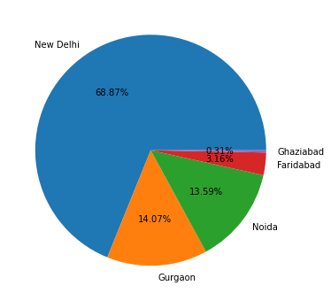

```python
plt.pie(city_names_count[:5], labels=city_names[:5],autopct="%.2f%%")
```

### Observation:

New Delhi has maximum number of orders followed by gurgaon and noida.

### Ques: Top 10 Cusines

```python
#Method 1
final_df["Cuisines"].value_counts().head(10)
```

```
North Indian                      936
North Indian, Chinese             511
Fast Food                         354
Chinese                           354
North Indian, Mughlai             334
Cafe                              299
Bakery                            218
North Indian, Mughlai, Chinese    197
Bakery, Desserts                  170
Street Food                       149
Name: Cuisines, dtype: int64
```

```python
cuisine = final_df["Cuisines"].value_counts().index
cuisine
cuisine_count = final_df["Cuisines"].value_counts().values
cuisine_count
```

```
array([936, 511, 354, ...,   1,   1,   1], dtype=int64)
```

```
 [Text(0.4175823090707363, 1.0176566292965188, 'North Indian'),
 [Text(0.22777216858403795, 0.5550854341617375, '37.61%'),
```

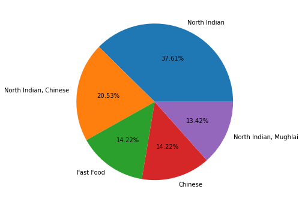

```python
#plt.pie(city_names_count[:5], labels=city_names[:5],autopct="%.2f%%")
plt.pie(cuisine_count[:5], labels=cuisine[:5], autopct="%.2f%%")
```

### Observation:

North Indian was the most ordered Cuisine.